# Equilibrium in CHNOSZ

Jeffrey M. Dick

This vignette was compiled on 2025-05-20 with CHNOSZ version 2.1.0-72.

Scope of this document:

- This document defines the concepts underlying equilibrium calculations with the `equilibrate()` function in CHNOSZ.
- Some illustrative examples of equilibrium calculations are provided, using proteins as a case study.
- The main use case for `equilibriate()` is to calculate and visualize distributions of aqueous species subject to the limitations below.
- A different function, `solubility()`, can be used to obtain the distributions of aqueous species in equilibrium with one or more minerals.
- Many types of relative stability diagrams (e.g. mineral and aqueous species predominance diagrams) can be made using the *maximum affinity method* (basis - species - [affinity|mosaic] - diagram) and do not require either of the `equilibrate()` or `solubility()` functions.

Limitations:

- CHNOSZ is not a general-purpose speciation code.
- The types of equilibrium calculations it can handle are restricted to systems described as *balanced on an element*.
  - For example, we can predict the distribution of aqueous Au complexes with given activities of chloride, hydroxide, and sulfide.
  - But we can not at the same time predict the formation of species without Au (such as NaCl(aq)), which would be required for a complete equilibrium model.
- Protein length can be used as the balancing constraint instead of an element.

## Concepts

**System**

Chemical system defined by formed species (referred to simply as species) and basis species, which are analogous to thermodynamic components. The possible species are any that are available in the OBIGT thermodynamic database.

**Species**

Selection of possible chemical species for which you want to calculate relative stabilities.

**Basis species**

Any minimal set of possible species that can be used to balance the formation reactions of the species. Additionally, in CHNOSZ the number of basis species must be equal to the number of elements.

**Formation reaction**

Chemical reaction giving the stoichiometry of basis species combined to make 1 mole of a species.

**Transformation reaction**

Any combination of two formation reactions in opposite directions (1 mole of a species reacts to form 1 mole of another species).

**Balancing coefficients**

(*n*<sub>balance</sub>) For a system that is balanced on one of the basis species, the number of moles of that basis species in the formation reaction of each of the species. The number can be positive or negative but not zero. Can also represent a virtual quantity, such as 1 (balance on moles of species) or number of amino acids in a protein sequence (balance on protein length).

**Speciation diagram**

Diagram showing the equilibrium activities of species as a function of one variable.

**Predominance diagram**

Diagram variables showing fields for species with highest equilibrium activity as a function of two variables. Also known as an equal activity diagram for aqueous species or stability diagram for minerals.

**Chemical affinity**

Negative of the differential of Gibbs energy of a system with respect to reaction progress. For a given reaction, chemical affinity is the negative of Gibbs energy of reaction: *A* = 2.303*RT*log(*K*/*Q*), where *K* is the equilibrium constant and *Q* is the activity quotient of species in the reaction (log here denotes base-10 logarithms, i.e. `log10` in R).

**Maximum affinity method**

Approach used to construct predominance diagrams not by finding the highest activity at equilibrium but by finding the highest affinity at a **reference activity**. The reference activities are user-defined equal activities of species (e.g. unit activity for minerals and 10<sup>-3</sup> for aqueous species).

**Equilibration method**

Calculations of the activities of species in equilibrium.

**Metastable equilibrium**

The condition that the affinities of all *transformation* reactions are zero. Implemented with the `equilibrate()` function in CHNOSZ, which is used below.

**Stable equilibrium**

The condition that the affinities of all *formation* reactions are zero. Implemented with the `solubility()` function in CHNOSZ, which is not described here.

## Example 1: Amino acids

In this sytem the basis species are CO<sub>2</sub>, H<sub>2</sub>O, NH<sub>3</sub>, H<sub>2</sub>S, and O<sub>2</sub> and the formed species are 20 amino acids.

```r
library(CHNOSZ)
reset()
basis("CHNOS")
species(aminoacids(""))
```

These functions are used for the different diagrams in the figure.

```r
aaA <- function() {
  a <- affinity(O2 = c(-90, -70), H2O = c(-20, 10))
  diagram(a, balance = 1, names = aa)
}

aaB <- function() {
  a <- affinity(O2 = c(-90, -70), H2O = c(-20, 10))
  e <- equilibrate(a, balance = 1)
  diagram(e, names = aa)
}

aaC <- function() {
  a <- affinity(O2 = c(-71, -66), H2O = c(-8, 4))
  diagram(a, balance = "CO2", names = aa)
}

aaD <- function() {
  a <- affinity(O2 = c(-71, -66), H2O = c(-8, 4))
  e <- equilibrate(a, balance = "CO2")
  diagram(e, names = aa)
}

aaE <- function() {
  basis("O2", -66)
  a <- affinity(H2O = c(-8, 4))
  e <- equilibrate(a, balance = "CO2")
  diagram(e, ylim = c(-5, -1), names = aa)
}

aaF <- function() {
  species(1:20, -7)
  a <- affinity(H2O = c(-8, 4))
  e <- equilibrate(a, balance = "CO2")
  diagram(e, ylim = c(-8, -4), names = aa)
}
```

The labels used for the diagrams are the one-letter abbreviations for the amino acids.

```r
aa <- aminoacids()
aa
```

```
##  [1] "A" "C" "D" "E" "F" "G" "H" "I" "K" "L" "M" "N" "P" "Q" "R" "S" "T" "V" "W" "Y"
```

Press the button to show all of the code for making the figure.

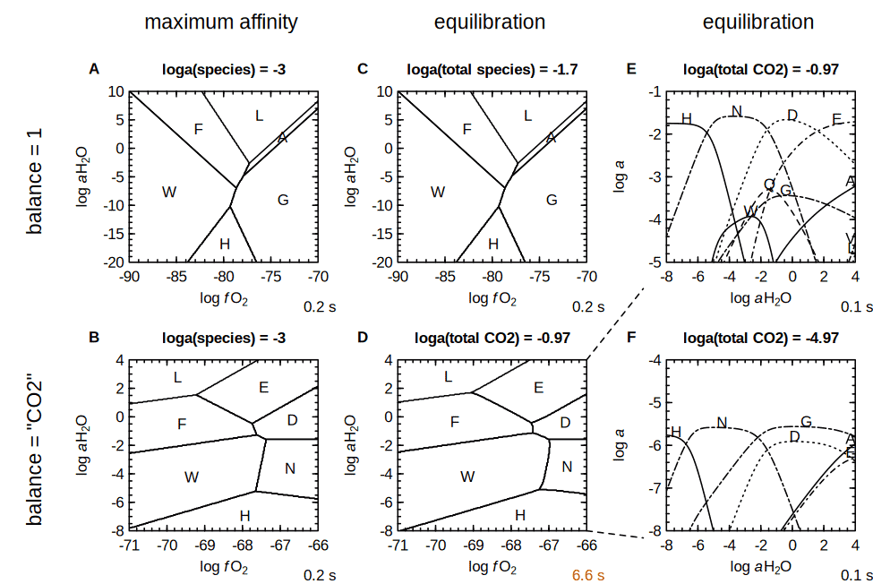

## Example 2: Proteins

In this sytem the basis species are CO<sub>2</sub>, H<sub>2</sub>O, NH<sub>3</sub>, H<sub>2</sub>S, O<sub>2</sub>, and H<sup>+</sup> and the formed species are 6 proteins from the set of archaeal and bacterial surface layer proteins considered by Dick (2008).

The inclusion of charge in the basis species (with H<sup>+</sup>) allows ionization of proteins to be calculated (Dick et al., 2006).

```r
basis("CHNOS+")
organisms <- c("METJA", "HALJP", "METVO", "ACEKI", "GEOSE", "BACLI")
proteins <- c(rep("CSG", 3), rep("SLAP", 3))
species(proteins, organisms)
```

Here are the lengths of the proteins.

```r
protein.length(species()$name)
```

```
## [1]  530  828  553  736 1198  844
```

These functions are used for the different diagrams in the figure.

```r
prA <- function() {
  a <- affinity(O2 = c(-90, -70), H2O = c(-20, 0))
  diagram(a, balance = "length", names = organisms)
}

prB <- function() {
  a <- affinity(O2 = c(-90, -70))
  e <- equilibrate(a, balance = "length")
  ylab <- quote(log~italic(a)~protein)
  diagram(e, names = organisms, ylim = c(-5, -1), ylab = ylab)
}

prC <- function() {
  a <- affinity(O2 = c(-90, -70), H2O = c(-20, 0))
  diagram(a, normalize = TRUE, names = organisms)
}

prD <- function() {
  a <- affinity(O2 = c(-90, -70))
  e <- equilibrate(a, normalize = TRUE)
  ylab <- quote(log~italic(a)~protein)
  diagram(e, names = organisms, ylim = c(-5, -1), ylab = ylab)
}

prE <- function() {
  a <- affinity(O2 = c(-90, -70), H2O = c(-20, 0))
  diagram(a, as.residue = TRUE, names = organisms)
}

prF <- function() {
  a <- affinity(O2 = c(-90, -70))
  e <- equilibrate(a, as.residue = TRUE, loga.balance = 0)
  ylab <- quote(log~italic(a)~residue)
  diagram(e, names = organisms, ylim = c(-3, 1), ylab = ylab)
}
```

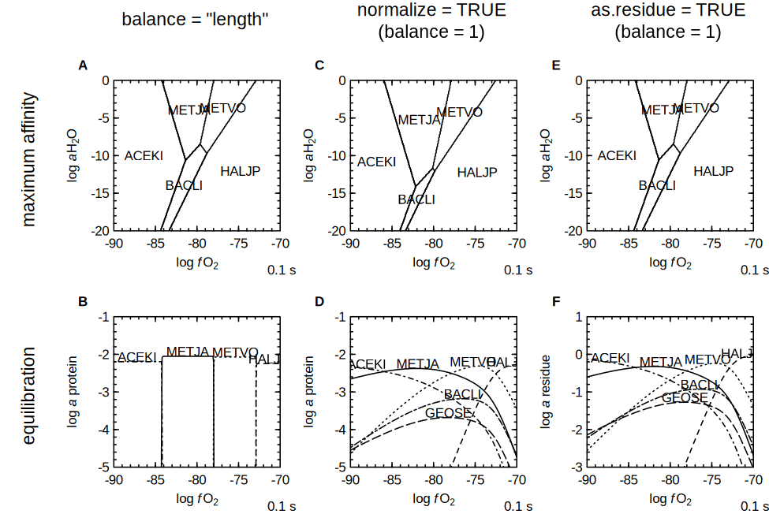

Diagrams **A**, **C**, and **E** are predominance (equal-activity) diagrams made with different balancing constraints. Diagrams **B**, **D**, and **F** show a cross-section of the same system at log*a*H<sub>2</sub>O = 0.

- In Diagrams **A** and **B**, the reactions are balanced on protein length. The drastic transitions between proteins in **B** result from the large balancing coefficients, which become exponents on activities in the expression for the activity quotient (*Q*).
- In Diagrams **C** and **D**, the chemical formulas of the proteins are *normalized*, or divided by the protein length, before the equilibration or maximum affinity calculation. However, the final diagram is not drawn for activities of these “residue equivalents”, but for rescaled activities of whole proteins. Because of the rescaling, the fields of the shorter METJA and METVO proteins grow at the expense of the longer BACLI protein.
- Diagrams **E** and **F** are like the normalization calculation, except that the final diagram is drawn for the residue equivalents and not the whole proteins. The predominance diagram is the same as that for non-normalized reactions (**A**), but the equilibrium activities of residues are higher than those of the proteins.

## Example 3: Normalization

Here is another figure showing the effects of normalization. This is like Figure 5 of Dick (2008), extended to more extreme conditions. If you wish to reproduce the diagram from the 2008 paper more closely, uncomment the `mod.OBIGT()` commands.

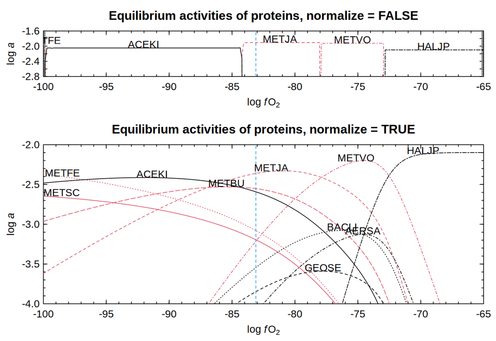

```r
## Use superseded properties of [Met], [Gly], and [UPBB] (Dick et al., 2006)
#mod.OBIGT("[Met]", G = -35245, H = -59310, S = 40.38)
#mod.OBIGT("[Gly]", G = -6075, H = -5570, S = 17.31)
#mod.OBIGT("[UPBB]", G = -21436, H = -45220, S = 1.62)
organisms <- c("METSC", "METJA", "METFE",  "METVO", "METBU",
               "HALJP", "ACEKI", "GEOSE", "BACLI", "AERSA")
proteins <- c(rep("CSG", 6), rep("SLAP", 4))
# Use red for Methano* genera
col <- c(rep(2, 5), rep(1, 5))
basis("CHNOS+")
species(proteins, organisms)
a <- affinity(O2 = c(-100, -65))
layout(matrix(1:2), heights = c(1, 2))
e <- equilibrate(a)
diagram(e, ylim = c(-2.8, -1.6), names = organisms, col = col)
water.lines(e, col = 4)
title(main="Equilibrium activities of proteins, normalize = FALSE")
e <- equilibrate(a, normalize = TRUE)
diagram(e, ylim = c(-4, -2), names = organisms, col = col)
water.lines(e, col = 4)
title(main = "Equilibrium activities of proteins, normalize = TRUE")
```

Although it is below the stability limit of H<sub>2</sub>O (vertical dashed line), there is an interesting convergence of the metastable equilibrium activities of some proteins at low log *f*O<sub>2</sub>.

## Example 4: Metastable Equilibrium Steps

The `protein.equil()` function carries out individual steps in the calculation of metastable equilibrium. This example uses two proteins to follow the example described by Dick and Shock (2011).

```r
# Start with fresh OBIGT database
reset()
```

```
## reset: resetting "thermo" object
```

```
## OBIGT: loading default database with 2026 aqueous, 3580 total species
```

```r
# Use superseded properties of [Met], [Gly], and [UPBB] (Dick et al., 2006)
mod.OBIGT("[Met]", G = -35245, H = -59310, S = 40.38)
```

```
## mod.OBIGT: updated [Met](aq)
```

```
## [1] 1794
```

```r
mod.OBIGT("[Gly]", G = -6075, H = -5570, S = 17.31)
```

```
## mod.OBIGT: updated [Gly](aq)
```

```
## [1] 1787
```

```r
mod.OBIGT("[UPBB]", G = -21436, H = -45220, S = 1.62)
```

```
## mod.OBIGT: updated [UPBB](aq)
```

```
## [1] 1806
```

```r
# Set up the basis species to those used in DS11
basis("CHNOS+")
```

```
##     C H N O S Z ispecies logact state
## CO2 1 0 0 2 0 0      690     -3    aq
## H2O 0 2 0 1 0 0        1      0   liq
## NH3 0 3 1 0 0 0       64     -4    aq
## H2S 0 2 0 0 1 0       65     -7    aq
## O2  0 0 0 2 0 0     2772    -80   gas
## H+  0 1 0 0 0 1        3     -7    aq
```

```r
# Note this yields logaH2 = -4.657486
swap.basis("O2", "H2")
```

```
## subcrt: 6 species at 25 ºC and 1 bar (wet) [energy units: J]
```

```
## subcrt: 6 species at 25 ºC and 1 bar (wet) [energy units: J]
```

```
##     C H N O S Z ispecies    logact state
## CO2 1 0 0 2 0 0      690 -3.000000    aq
## H2O 0 2 0 1 0 0        1  0.000000   liq
## NH3 0 3 1 0 0 0       64 -4.000000    aq
## H2S 0 2 0 0 1 0       65 -7.000000    aq
## H2  0 2 0 0 0 0       62 -4.657388    aq
## H+  0 1 0 0 0 1        3 -7.000000    aq
```

```r
# Demonstrate the steps of the equilibrium calculation
protein <- pinfo(c("CSG_METVO", "CSG_METJA"))
protein.equil(protein, loga.protein = -3)
```

```
## protein.equil: temperature from argument is 25 degrees C
```

```
## protein.equil: energy units is J
```

```
## protein.equil: pH from thermo$basis is 7
```

```
## protein.equil: [Met] is from reference DLH06
```

```
## protein.equil [1]: first protein is CSG_METVO with length 553
```

```
## protein.equil [1]: reaction to form nonionized protein from basis species has G0(J/mol) of -199100000
```

```
## protein.equil [1]: ionization reaction of protein has G0(J/mol) of -400900
```

```
## protein.equil [1]: per residue, reaction to form ionized protein from basis species has G0/RT of -145.5
```

```
## protein.equil [1]: per residue, logQstar is 63
```

```
## protein.equil [1]: per residue, Astar/RT = -G0/RT - 2.303logQstar is 0.4377
```

```
## check it!       per residue, Astar/RT calculated using affinity() is 0.4377
```

```
## protein.equil [all]: lengths of all proteins are 553 530
```

```
## protein.equil [all]: Astar/RT of all residue equivalents are 0.4377 1.367
```

```
## protein.equil [all]: sum of exp(Astar/RT) of all residue equivalents is 5.472
```

```
## protein.equil [all]: equilibrium degrees of formation (alphas) of residue equivalents are 0.2831 0.7169
```

```
## check it!     alphas of residue equivalents from equilibrate() are 0.2831 0.7169
```

```
## protein.equil [all]: for activity of proteins equal to 10^-3, total activity of residues is 10^0.03463
```

```
## protein.equil [all]: log10 equilibrium activities of residue equivalents are -0.5134 -0.1099
```

```
## protein.equil [all]: log10 equilibrium activities of proteins are -3.256 -2.834
```

```
## check it!    log10 eq'm activities of proteins from equilibrate() are -3.256 -2.834
```

[output not shown]

```r
## We can also look at the affinities
# (Reaction 7, Dick and Shock, 2011)
# A/2.303RT for protein at unit activity (A-star for the protein)
a <- affinity(iprotein = protein[1], loga.protein = 0)
```

```
## affinity: temperature is 25 ºC
```

```
## affinity: pressure is Psat
```

```
## subcrt: 27 species at 25 ºC and 1 bar (wet) [energy units: J]
```

```
## affinity: ionizing proteins ...
```

```
## subcrt: 18 species at 25 ºC and 1 bar (wet) [energy units: J]
```

```r
Astar.protein <- a$values[[1]]
# Divide affinity by protein length (A-star for the residue)
pl <- protein.length(protein[1])
Astar.residue <- a$values[[1]]/pl  # 0.1893, Eq. 11
# A/2.303RT per residue corresponding to protein activity of 10^-3
loga.residue <- log10(pl*10^-3)
Aref.residue <- Astar.residue - loga.residue  # 0.446, after Eq. 16
# A-star of the residue in natural log units (A/RT)
log(10) * Astar.residue  # 0.4359, after Eq. 23
```

```
## [1] 0.4377098
```

```r
# Reset changes to database
reset()
```

```
## reset: resetting "thermo" object
```

```
## OBIGT: loading default database with 2026 aqueous, 3580 total species
```

## Document history

- 2009-11-29 Initial version with CSG example, titled “Calculating relative abundances of proteins”
- 2012-09-30 Renamed to “Equilibrium in CHNOSZ”; remove activity comparisons and add maximum affinity method.
- 2015-11-08 Move previous material to Appendix and add sections on concepts, organization, examples, and applications; use knitr vignette engine.
- 2020-07-10 Simplify to concepts and examples (amino acids, proteins, normalization); convert document from LaTeX (Rnw) to R Markdown (Rmd).
- 2025-05-11 Moved vignette to JMDplots and merged with `protein.equil()` demo from CHNOSZ.

## References

Dick JM. 2008. Calculation of the relative metastabilities of proteins using the CHNOSZ software package. *Geochemical Transactions* **9**: 10. doi: 10.1186/1467-4866-9-10

Dick JM, LaRowe DE, Helgeson HC. 2006. Temperature, pressure, and electrochemical constraints on protein speciation: Group additivity calculation of the standard molal thermodynamic properties of ionized unfolded proteins. *Biogeosciences* **3**(3): 311–336. doi: 10.5194/bg-3-311-2006

Dick JM, Shock EL. 2011. Calculation of the relative chemical stabilities of proteins as a function of temperature and redox chemistry in a hot spring. *PLOS One* **6**(8): e22782. doi: 10.1371/journal.pone.0022782